## Section 1.2 exercises

1. How many rows are in `penguins`? How many columns?  
   A: 344 rows and 8 columns.
2. What does the `bill_depth_mm` variable in the `penguins` data frame describe? Read the help for `?penguins` to find out.  
   A: a number denoting bill depth in millimeters.
3. Make a scatterplot of `bill_depth_mm` vs. `bill_length_mm`. That is, make a scatterplot with `bill_depth_mm` on the y-axis and `bill_length_mm` on the x-axis. Describe the relationship between these two variables.  
   A: roughly a positive correlation within species.

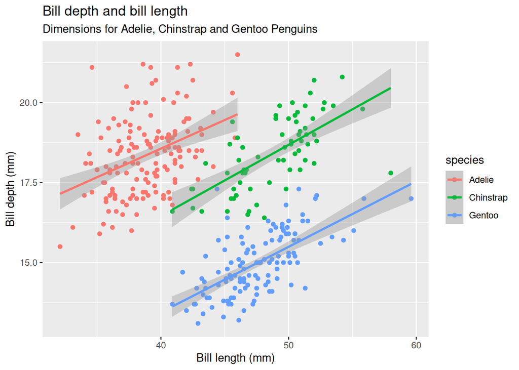

   ```r
   ggplot(data = penguins,
          mapping = aes(x = bill_length_mm, y = bill_depth_mm, color = species)) +
     geom_point() +
     geom_smooth(method = "lm") +
     labs(
       title = "Bill depth and bill length",
       subtitle = "Dimensions for Adelie, Chinstrap and Gentoo Penguins",
       x = "Bill length (mm)", y = "Bill depth (mm)"
     )
   ```

4. What happens if you make a scatterplot of `species` vs. `bill_depth_mm`? What might be a better choice of geom?  
   A:

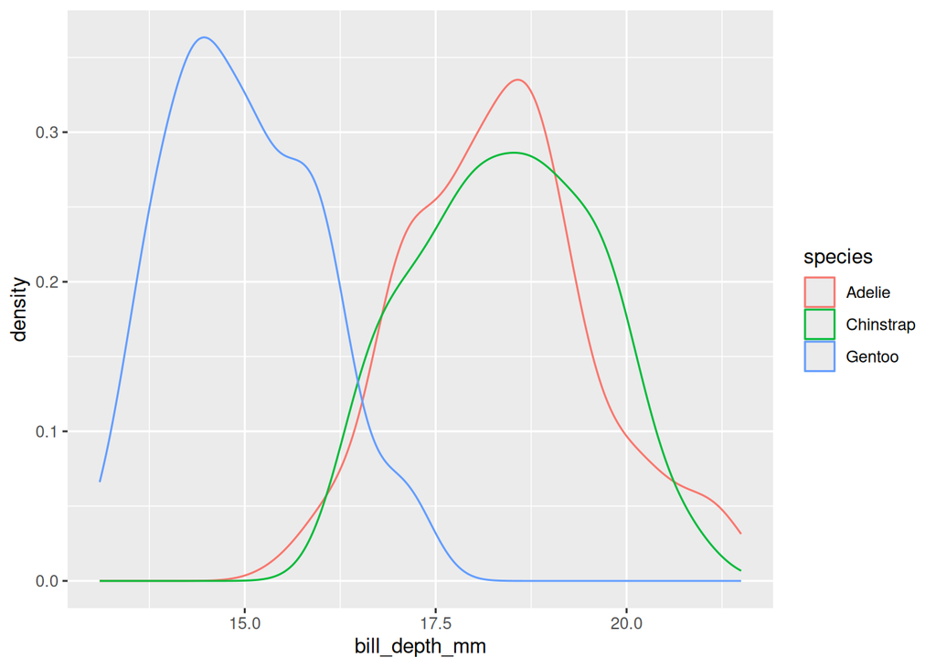

   ```r
   ggplot(data = penguins,
          mapping = aes(x = bill_depth_mm)) +
     geom_density(mapping = aes(color = species))
   ```

5. Why does the following give an error and how would you fix it?  
   A: the geom is missing aesthetics `x` and `y`.

   ```r
   ggplot(data = penguins) +
     geom_point()
   ```

6. What does the `na.rm` argument do in `geom_point()`? What is the default value of the argument? Create a scatterplot where you successfully use this argument set to `TRUE`.  
   A: this argument set to `TRUE` automatically removes `N/A` values.

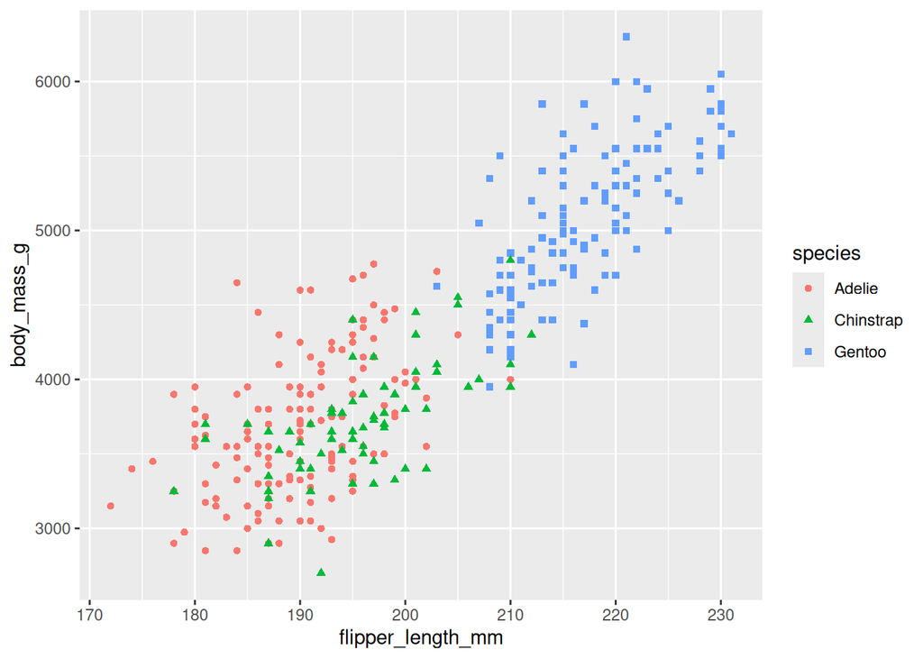

   ```r
   ggplot(data = penguins,
          mapping = aes(x = flipper_length_mm, y = body_mass_g)) +
     geom_point(mapping = aes(color = species, shape = species), na.rm = TRUE)
   ```

7. Add the following caption to the plot you made in the previous exercise: “Data come from the palmerpenguins package.” Hint: Take a look at the documentation for `labs()`.  
   A: captions are associated with the `caption` argument in `lab()`.

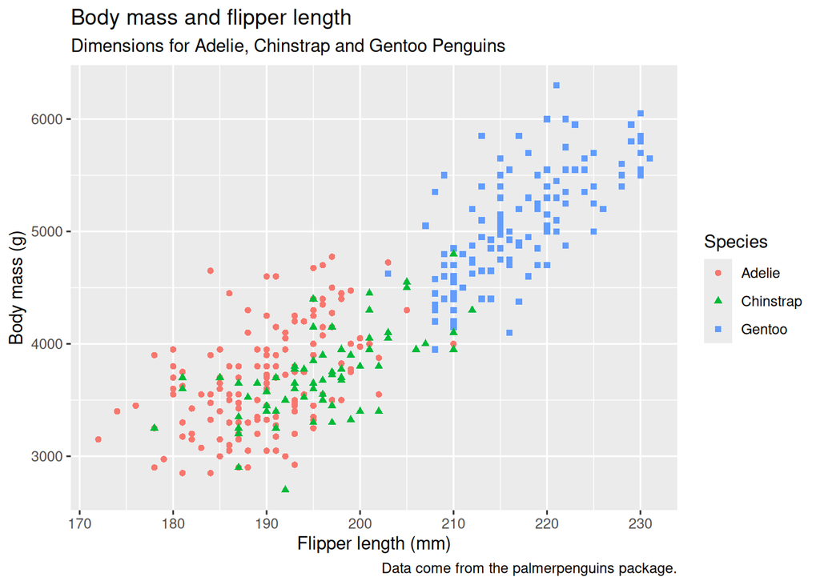

   ```r
   ggplot(data = penguins,
          mapping = aes(x = flipper_length_mm, y = body_mass_g)) +
     geom_point(mapping = aes(color = species, shape = species), na.rm = TRUE) +
     labs(
       title = "Body mass and flipper length",
       subtitle = "Dimensions for Adelie, Chinstrap and Gentoo Penguins",
       caption = "Data come from the palmerpenguins package.",
       x = "Flipper length (mm)", y = "Body mass (g)",
       color = "Species", shape = "Species"
     )
   ```

8. Recreate the following visualization. What aesthetic should `bill_depth_mm` be mapped to? And should it be mapped at the global level or at the geom level?  
   A: `bill_depth_mm` is mapped continuously to the color at the geom level.

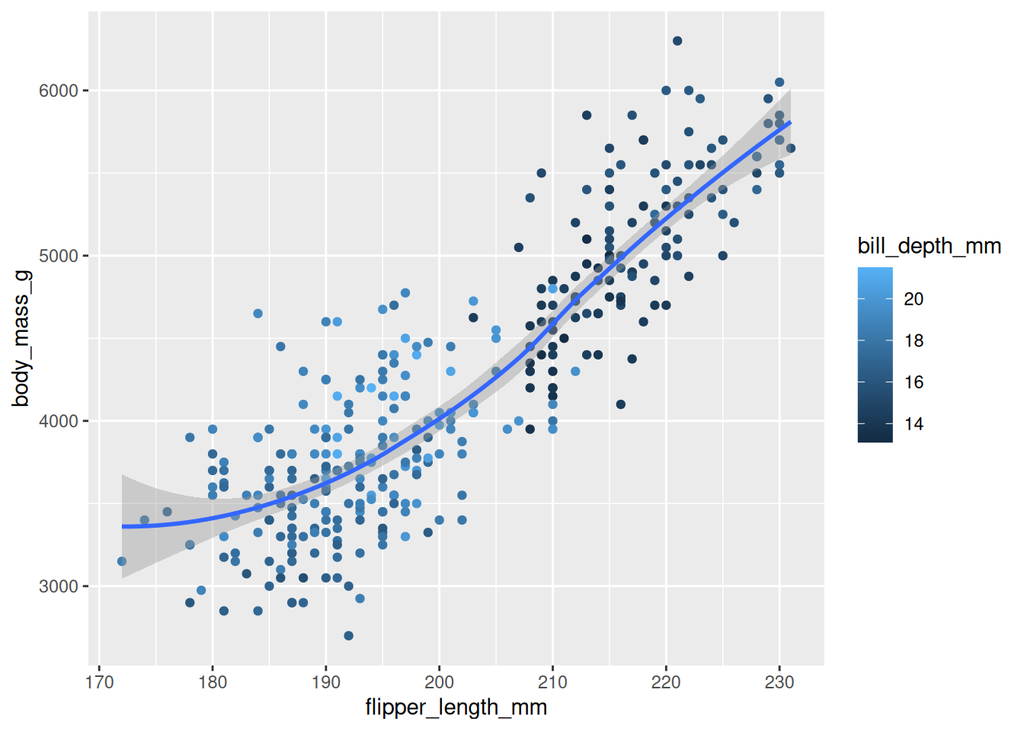

   ```r
   ggplot(
     data = penguins,
     mapping = aes(x = flipper_length_mm, y = body_mass_g)
   ) +
     geom_point(aes(color = bill_depth_mm)) +
     geom_smooth()
   ```

9. Run this code in your head and predict what the output will look like. Then, run the code in R and check your predictions.

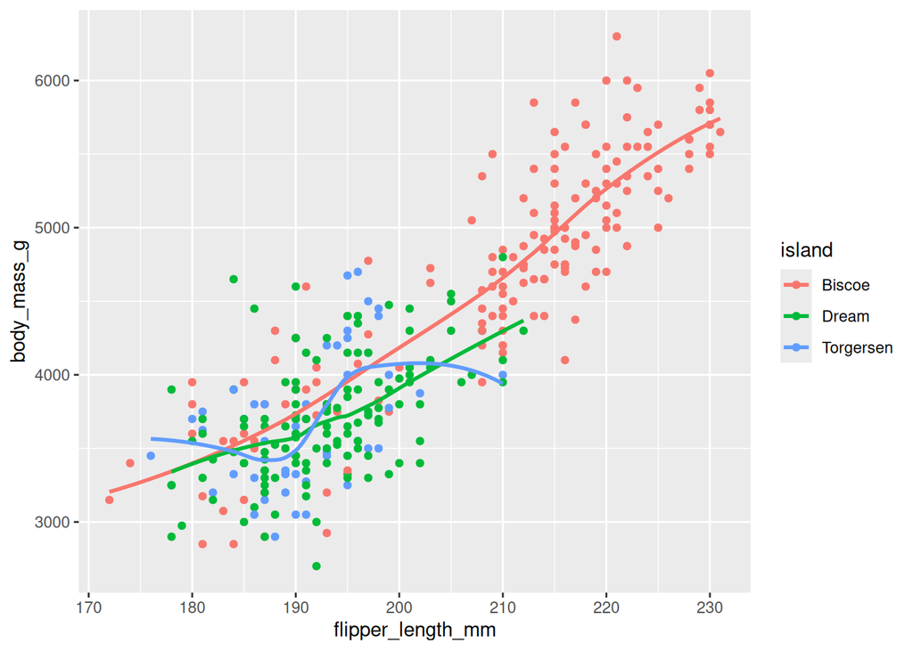

   ```r
   ggplot(
     data = penguins,
     mapping = aes(x = flipper_length_mm, y = body_mass_g, color = island)
   ) +
     geom_point() +
     geom_smooth(se = FALSE)
   ```

10. Will these two graphs look different? Why/why not?  
    A: they’re equivalent since the `mapping` argument in `ggplot()` is passed down to each subsequent geom layers.

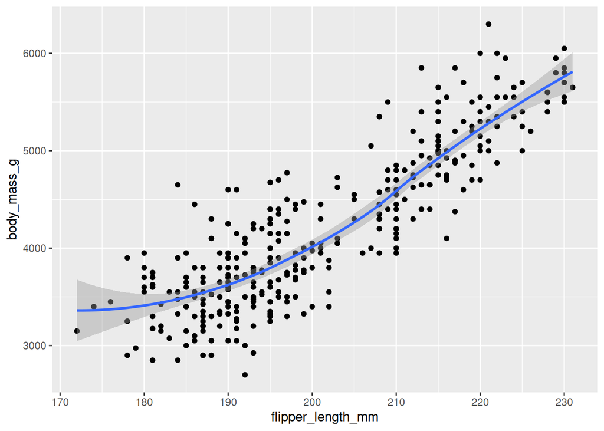

    ```r
    ggplot(
      data = penguins,
      mapping = aes(x = flipper_length_mm, y = body_mass_g)
    ) +
      geom_point() +
      geom_smooth()
    ```

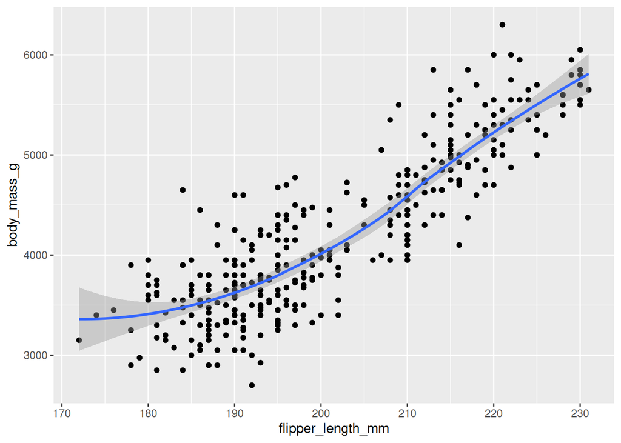

    ```r
    ggplot() +
      geom_point(
        data = penguins,
        mapping = aes(x = flipper_length_mm, y = body_mass_g)
      ) +
      geom_smooth(
        data = penguins,
        mapping = aes(x = flipper_length_mm, y = body_mass_g)
      )
    ```

## Section 1.4 exercises

1. Make a bar plot of `species` of `penguins`, where you assign `species` to the `y` aesthetic. How is this plot different?  
   A: the bars are displayed horizontally instead.

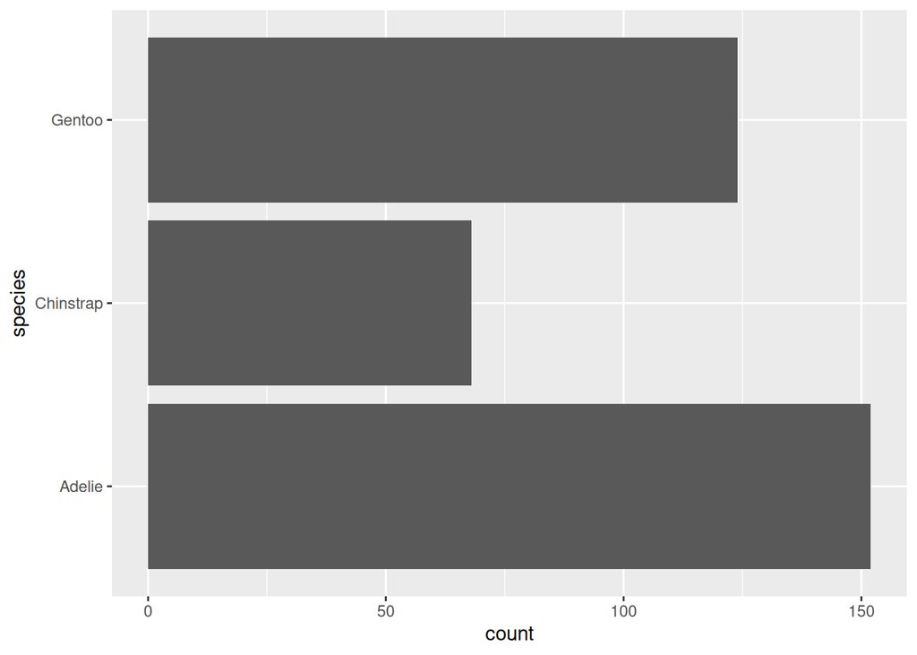

   ```r
   ggplot(penguins, aes(y = species)) +
     geom_bar()
   ```

2. How are the following two plots different? Which aesthetic, `color` or `fill`, is more useful for changing the color of bars?  
   A: the `color` argument only changes the border of the bars, while the `fill` argument fills the bars with specified color.

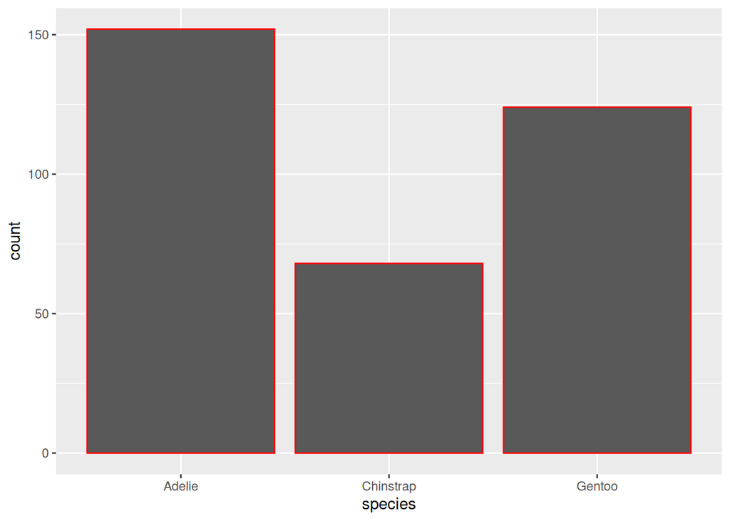

   ```r
   ggplot(penguins, aes(x = species)) +
     geom_bar(color = "red")
   ```

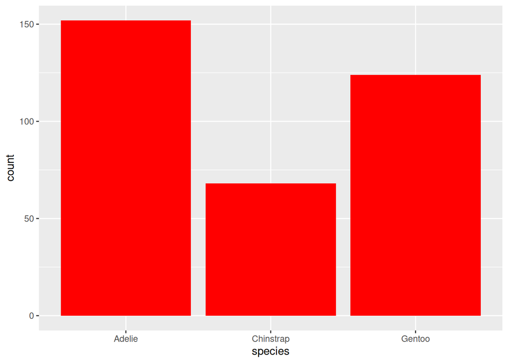

   ```r
   ggplot(penguins, aes(x = species)) +
     geom_bar(fill = "red")
   ```

3. What does the `bins` argument in `geom_histogram()` do?  
   A: specifies the number of bins the variable is partitioned into (as opposed to specifiying the width of each bin.)
4. Make a histogram of the `carat` variable in the `diamonds` dataset that is available when you load the tidyverse package. Experiment with different binwidths. What binwidth reveals the most interesting patterns?  
   A: `binwidth = 0.2` gives decent results.

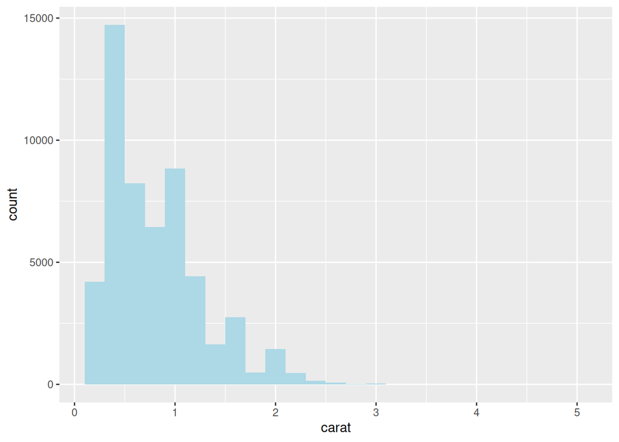

   ```r
   ggplot(diamonds, aes(x = carat)) +
     geom_histogram(binwidth = 0.2, fill = "lightblue")
   ```

# Section 1.5 exercises

1. The `mpg` data frame that is bundled with the ggplot2 package contains 234 observations collected by the US Environmental Protection Agency on 38 car models. Which variables in `mpg` are categorical? Which variables are numerical? (Hint: Type `?mpg` to read the documentation for the dataset.) How can you see this information when you run `mpg`?
2. Make a scatterplot of `hwy` vs. `displ` using the `mpg` data frame. Next, map a third, numerical variable to `color`, then `size`, then both `color` and `size`, then `shape`. How do these aesthetics behave differently for categorical vs. numerical variables?  
   A: continuous variables cannot be mapped to the `shape` aesthetic.

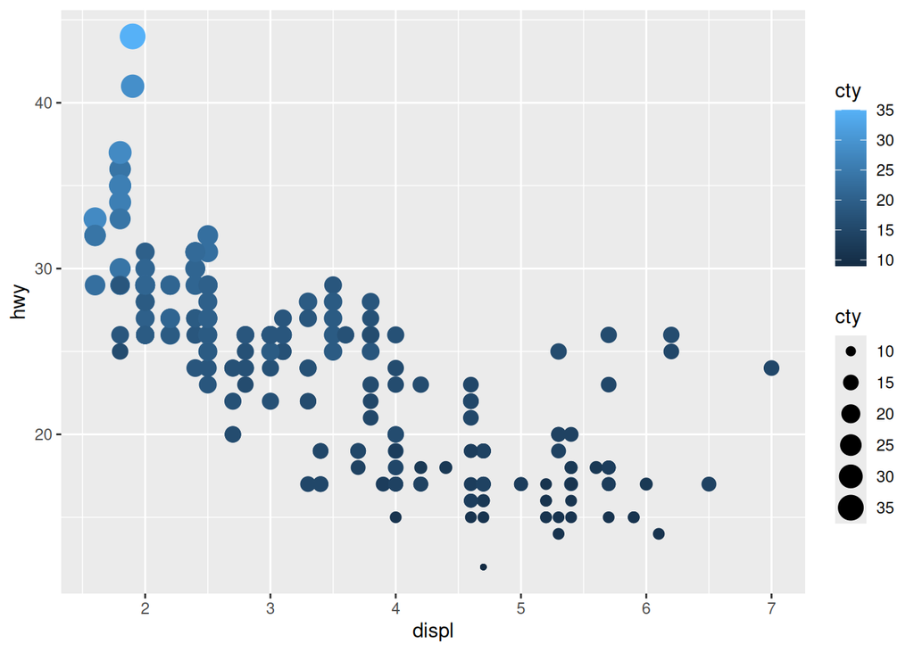

   ```r
   ggplot(data = mpg,
          mapping = aes(x = displ, y = hwy, color = cty, size = cty)) +
     geom_point()
   ```

3. In the scatterplot of `hwy` vs. `displ`, what happens if you map a third variable to `linewidth`?  
   A: nothing happens.

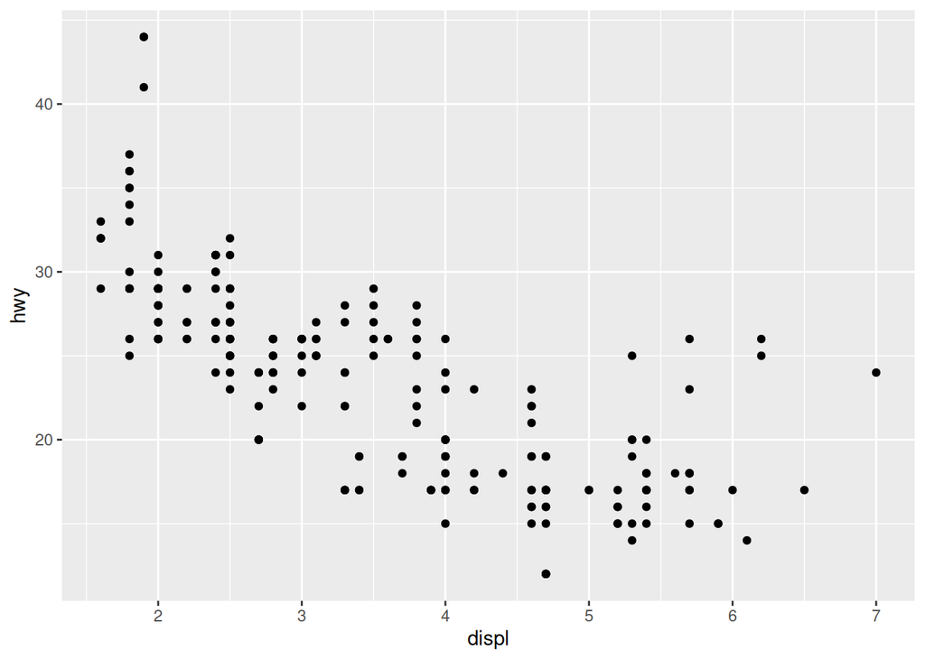

   ```r
   ggplot(data = mpg,
          mapping = aes(x = displ, y = hwy, linewidth = cty)) +
     geom_point()
   ```

4. What happens if you map the same variable to multiple aesthetics?  
   A: then it corresponds to multiple aesthetics, as shown in exercise 1.5.2.
5. Make a scatterplot of `bill_depth_mm` vs. `bill_length_mm` and color the points by `species`. What does adding coloring by species reveal about the relationship between these two variables? What about faceting by `species`?  
   A: as shown in exercise 1.2.3, there’s roughly a positive correlation within each species.

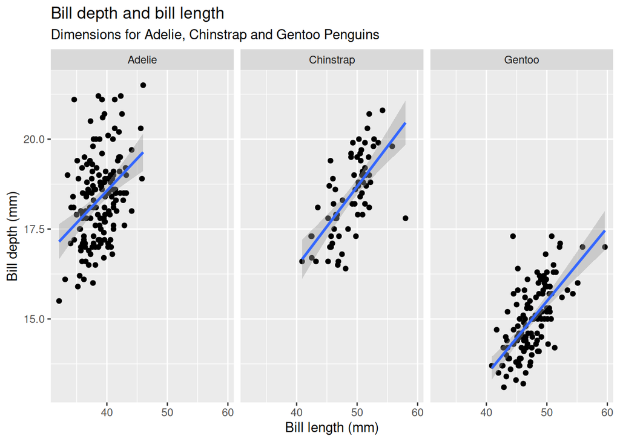

   ```r
   ggplot(data = penguins,
          mapping = aes(x = bill_length_mm, y = bill_depth_mm)) +
     geom_point() +
     geom_smooth(method = "lm") +
     labs(
       title = "Bill depth and bill length",
       subtitle = "Dimensions for Adelie, Chinstrap and Gentoo Penguins",
       x = "Bill length (mm)", y = "Bill depth (mm)"
     ) +
     facet_wrap(~species)
   ```

6. Why does the following yield two separate legends? How would you fix it to combine the two legends?

   ```r
   ggplot(
     data = penguins,
     mapping = aes(
       x = bill_length_mm, y = bill_depth_mm,
       color = species, shape = species
     )
   ) +
     geom_point() +
     labs(color = "Species")
   ```

   A: they’re separated since the legend is only specified for one. Below is the fixed version of the plot.

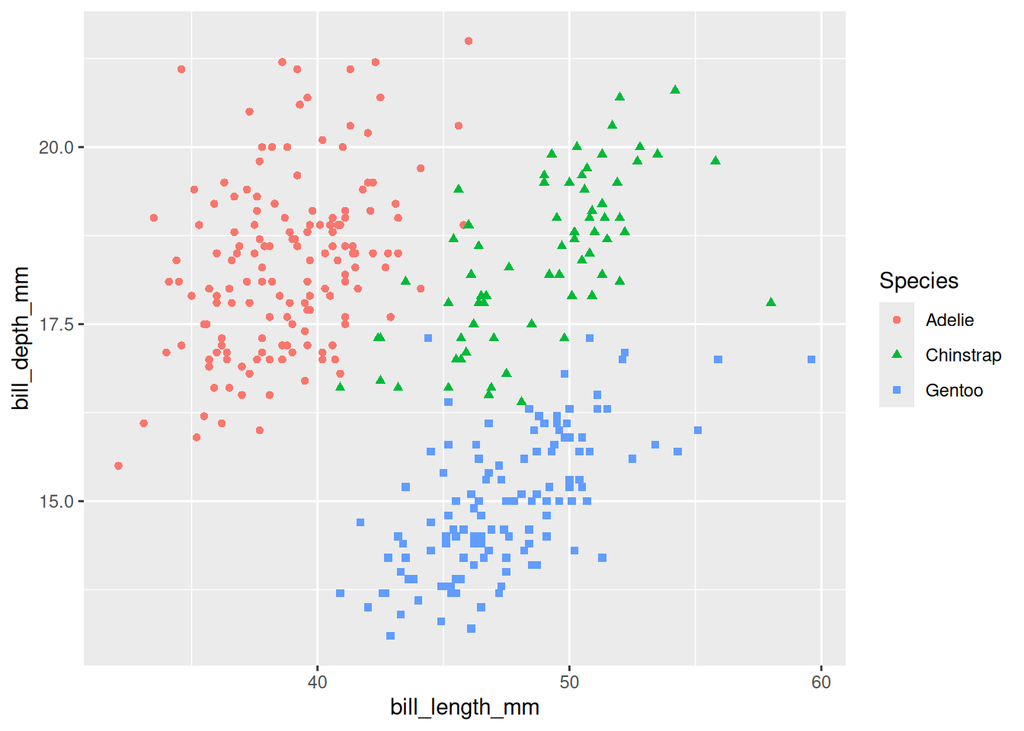

   ```r
   ggplot(
     data = penguins,
     mapping = aes(
       x = bill_length_mm, y = bill_depth_mm,
       color = species, shape = species
     )
   ) +
     geom_point() +
     labs(color = "Species", shape = "Species")
   ```

7. Create the two following stacked bar plots. Which question can you answer with the first one? Which question can you answer with the second one?  
   A: They show the proportion of the different species on each island and the distribution on the islands of each species respectively.

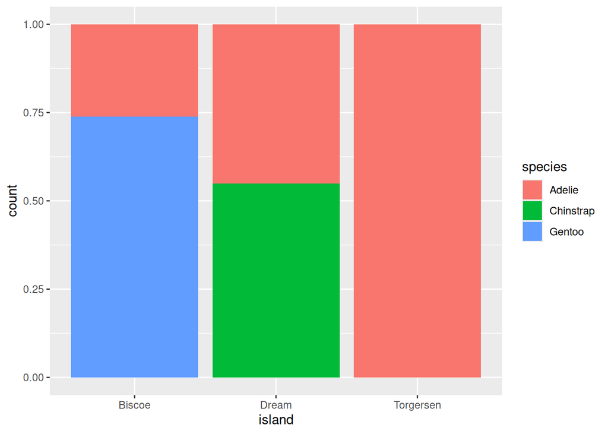

   ```r
   ggplot(penguins, aes(x = island, fill = species)) +
     geom_bar(position = "fill")
   ```

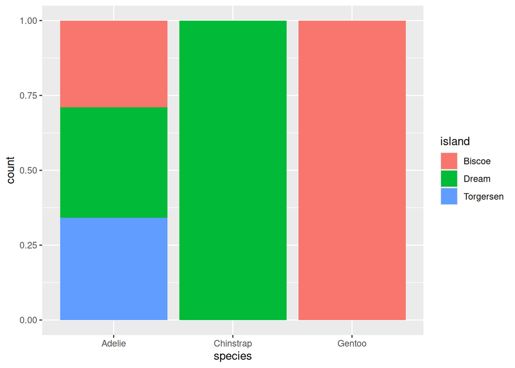

   ```r
   ggplot(penguins, aes(x = species, fill = island)) +
     geom_bar(position = "fill")
   ```

## Section 1.6 exercises

1. Run the following lines of code. Which of the two plots is saved as `mpg-plot.png`? Why?  
   A: the latter one, as `ggsave()` defaults to fetching the last plot generated.

   ```r
   ggplot(mpg, aes(x = class)) +
     geom_bar()
   ggplot(mpg, aes(x = cty, y = hwy)) +
     geom_point()
   ggsave("mpg-plot.png")
   ```

2. What do you need to change in the code above to save the plot as a PDF instead of a PNG? How could you find out what types of image files would work in `ggsave()`?  
   A: simply changing the file extension would work, or formally, one specifies `device` as one of “png”, “eps”, “ps”, “tex” (pictex), “pdf”, “jpeg”, “tiff”, “png”, “bmp”, “svg” or “wmf” (windows only). If NULL (default), the device is guessed based on the filename extension.

   ```r
   ggplot(mpg, aes(x = cty, y = hwy)) +
     geom_point()
   ggsave("mpg-plot.pdf")
   ```